# Hayman Fire Recovery

Bri Rick

2/3/2022

```r
library(tidyverse)
library(tidyr)
library(ggthemes)
library(lubridate)

# Now that we have learned how to munge (manipulate) data
# and plot it, we will work on using these skills in new ways

knitr::opts_knit$set(root.dir='..')
```

```r
####-----Reading in Data and Stacking it ----- ####
#Reading in files
files <- list.files('data',full.names=T)

#Read in individual data files
ndmi <- read_csv(files[1]) %>%
  rename(burned=2,unburned=3) %>%
  mutate(data='ndmi')

ndsi <- read_csv(files[2]) %>%
  rename(burned=2,unburned=3) %>%
  mutate(data='ndsi')

ndvi <- read_csv(files[3])%>%
  rename(burned=2,unburned=3) %>%
  mutate(data='ndvi')

# Stack as a tidy dataset
full_long <- rbind(ndvi,ndmi,ndsi) %>%
  gather(key='site',value='value',-DateTime,-data) %>%
  filter(!is.na(value))
```

## Question 1

Q: What is the correlation between NDVI and NDMI? - here I want you to convert the full_long dataset in to a wide dataset using the function “spread” and then make a plot that shows the correlation s a function of if the site was burned or not (x axis should be ndmi) You should exclude winter months and focus on summer months

*A: NDMI and NDVI are positively correlated, meaning that with higher NDMI there is higher NDVI.*

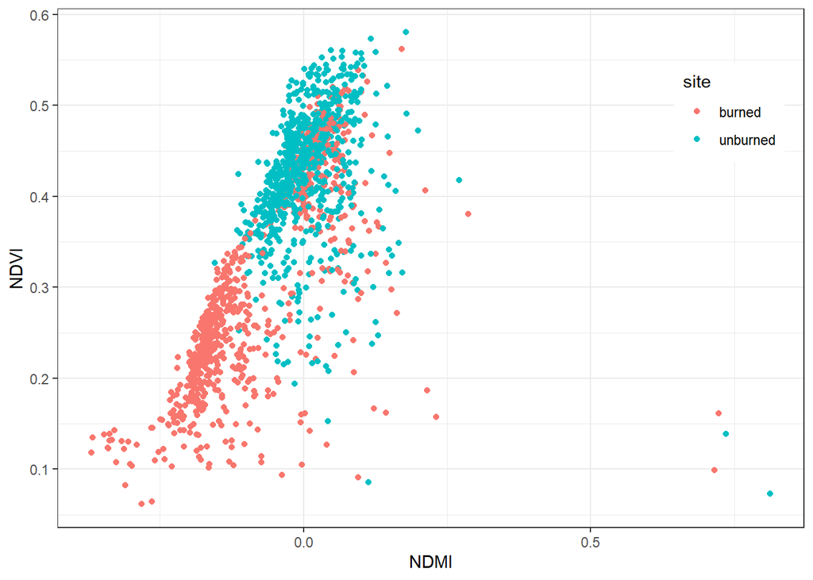

```r
#Convert from logn to wide dataset, exclude winter months
full_wide <- full_long %>% spread(key="data", value = "value") %>%
  mutate(month = month(DateTime))%>%
  filter(!is.na(ndvi),
         !is.na(ndsi),
         !is.na(ndmi))

full_wide_summer <- full_wide %>%
  filter(month %in% c(5, 6, 7, 8, 9))

#Plot NDMI vs NDVI colored by site type
ggplot(full_wide_summer, aes(x = ndmi, y = ndvi, color = site))+
  geom_point() +
  theme_bw()+
  xlab("NDMI")+
  ylab("NDVI")+
  theme(legend.position = c(0.9, 0.8))
```

## Question 2

Q: What is the correlation between average NDSI (normalized snow index) for January - April and average NDVI for June-August? In other words, does the previous year’s snow cover influence vegetation growth for the following summer?

*A: There doesn’t appear to be a strong correlation between average NDSI of the previous winter and average NDVI of the following summer. There is perhaps a small positive correlation.*

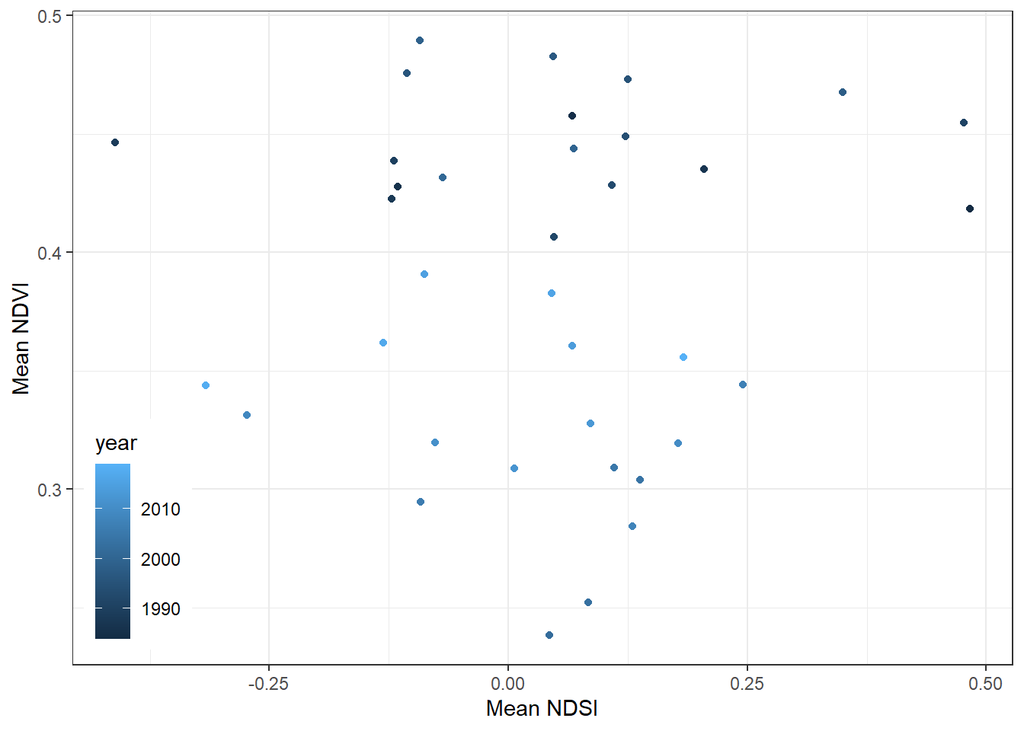

```r
#Calculate average NDVI for summer months
ndvi_summer <- full_wide %>%
  mutate(year=year(DateTime)) %>%
  filter(month %in% c(6, 7, 8)) %>%
  group_by(year) %>%
  summarize(mean_NDVI=mean(ndvi))

#Calculate average NDSI for winter months
ndsi_winter <- full_wide %>%
  mutate(year=year(DateTime)) %>%
  filter(month %in% c(1, 2, 3, 4)) %>%
  group_by(year) %>%
  summarize(mean_NDSI=mean(ndsi))

#Join NDVI and NDSI data together
ndvi_ndsi_avg <- inner_join(ndvi_summer, ndsi_winter, by = c("year"))

#Plot NDVI vs NDSI to look at correlation
ggplot(ndvi_ndsi_avg, aes(x = mean_NDSI, y = mean_NDVI, color = year))+
  geom_point()+
  xlab("Mean NDSI")+
  ylab("Mean NDVI")+
  theme_bw()+
  theme(legend.position = c(0.07, 0.2))
```

## Question 3

Q: How is the snow effect from question 2 different between pre- and post-burn and burned and unburned?

*A: Both NDVI and NDSI appear to be lower in the burned areas. This is likely due to a lack of vegetation which is measured directly by NDVI, and impacts NDSI by allowing more solar radiation in the winter which allows more snow to melt.*

*Burned sites post-fire have a much lower NDVI, and NDSI values do not reach as high as for pre-burned or unburned areas. Unburned and pre-fire sites have higher NDVI and NDSI values, though there doesn’t appear to be a strong correlation bewteen the two values.*

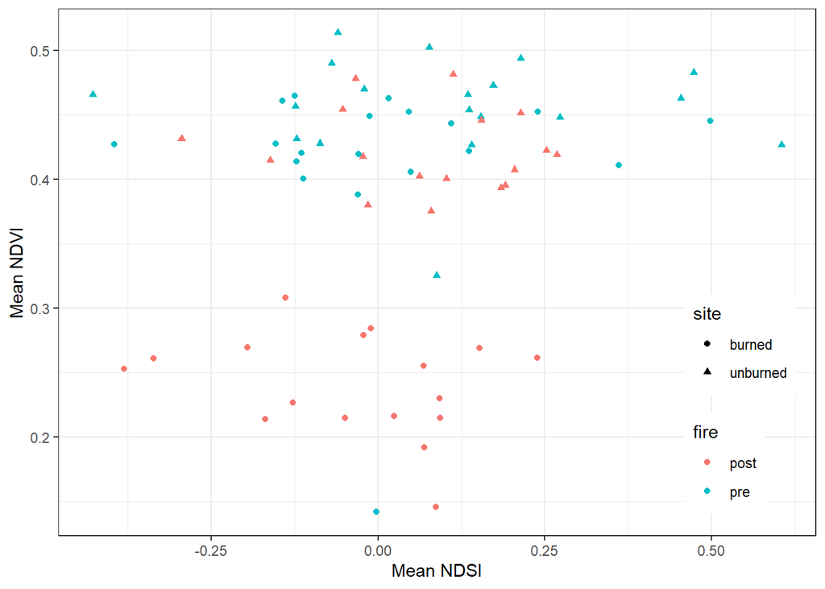

```r
#Calculate average NDVI for summer months separated by site type
ndvi_summer_site <- full_wide %>%
  mutate(year=year(DateTime)) %>%
  filter(month %in% c(6, 7, 8)) %>%
  group_by(year, site) %>%
  summarize(mean_NDVI=mean(ndvi)) %>%
  mutate(fire = if_else(year <= 2002, "pre", "post"))

#Calculate average NDSI for winter months separated by site type
ndsi_winter_site <- full_wide %>%
  mutate(year=year(DateTime)) %>%
  filter(month %in% c(1, 2, 3, 4)) %>%
  group_by(year, site) %>%
  summarize(mean_NDSI=mean(ndsi))%>%
  mutate(fire = if_else(year <= 2002, "pre", "post"))

#Join NDVI and NDSI data together by year and site type
ndvi_ndsi_avg_site <- inner_join(ndvi_summer_site, ndsi_winter_site, by = c("year", "site", "fire"))

#Plot NDVI vs NDSI coloring by site type
ggplot(ndvi_ndsi_avg_site, aes(x = mean_NDSI, y = mean_NDVI, color = fire, shape = site))+
  geom_point()+
  xlab("Mean NDSI") +
  ylab("Mean NDVI")+
  theme_bw()+
  theme(legend.position = c(0.9, 0.25))
```

## Question 4

Q: What month is the greenest month on average?

*A: The greenest month on average considering the burned and unburned sites together (black points) is August, however, looking at just the unburned site (blue points) the greenest month on average is September. The burned site (red points) is greenest in August.*

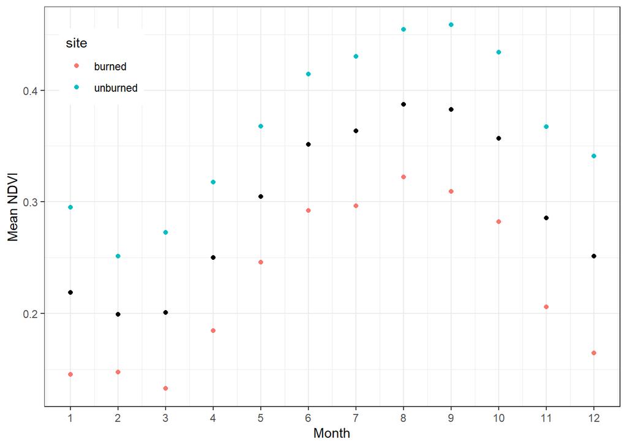

```r
#Calculate mean NDVI per month, per site type
ndvi_monthly_site <- full_wide %>%
  group_by(site,month) %>%
  summarize(mean_NDVI=mean(ndvi))

#Calculate mean NDVI per month
ndvi_monthly <- full_wide %>%
  group_by(month) %>%
  summarize(mean_NDVI=mean(ndvi))

#Plot average NDVI per month
ggplot()+
  geom_point(aes(x = month, y = mean_NDVI, color = site), data = ndvi_monthly_site) +
  geom_point(aes(x = month, y = mean_NDVI), data = ndvi_monthly) +
  xlab("Month")+
  ylab("Mean NDVI")+
  scale_x_continuous(breaks = seq(from = 1, to = 12, by = 1))+
  theme_bw() +
  theme(legend.position = c(0.1, 0.85))
```

## Question 5)

Q: What month is the snowiest on average?

*A: The snowiest month when considering all sites together (black points) is January. Considering only unburned sites (blue points), the snowiest month is February. January is the snowiest month for burned sites (red points).*

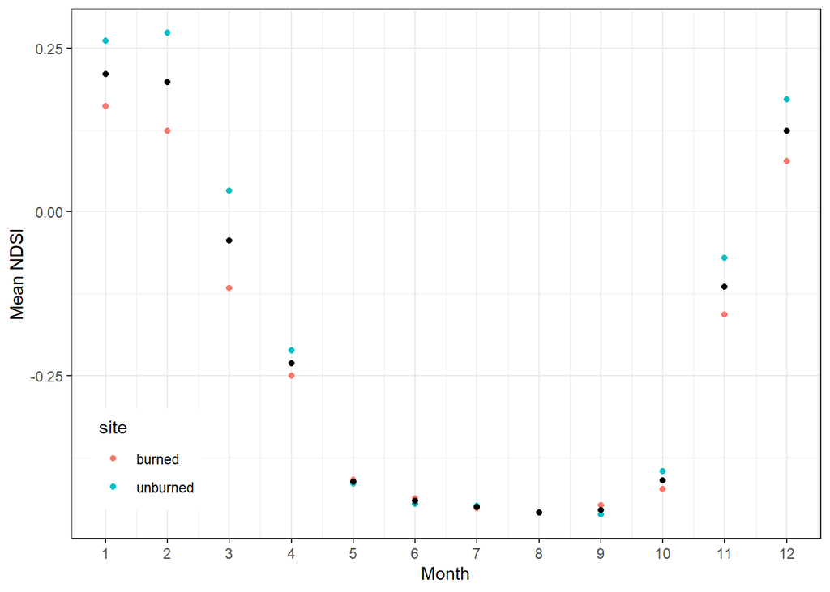

```r
#Calculate mean NDSI per month, per site type
ndsi_monthly_site <- full_wide %>%
  group_by(site,month) %>%
  summarize(mean_NDSI=mean(ndsi))

#Calculate mean NDSI per month
ndsi_monthly <- full_wide %>%
  group_by(month) %>%
  summarize(mean_NDSI=mean(ndsi))

#Plot mean NDSI per month
ggplot()+
  geom_point(aes(x = month, y = mean_NDSI, color = site), data = ndsi_monthly_site) +
  geom_point(aes(x = month, y = mean_NDSI), data = ndsi_monthly) +
  xlab("Month")+
  ylab("Mean NDSI")+
  scale_x_continuous(breaks = seq(from = 1, to = 12, by = 1))+
  theme_bw() +
  theme(legend.position = c(0.1, 0.15))
```